# NLP

Vidya Madhavan

## Libraries

```r
#Make sure you install and load the following libraries

library(tm)
```

```r
library(SnowballC)
library(wordcloud)
library(ggplot2)
library(tidyverse) #You will need the full tidyverse package not tidyr and dyplr separately
```

[output not shown]

[output not shown]

```r
library(topicmodels)

#IF USING A MAC PLEASE RUN THIS CODE
Sys.setlocale("LC_ALL", "C")
```

```
## [1] "C/C/C/C/C/en_US.UTF-8"
```

## In the class-notes folder you will find real csv files exported from real student’s note taking in this class. Import all document files and the list of weeks file

```r
library(tidyverse)

#Create a list of all the files, then loop over file list importing them and binding them together
D1 <- list.files(path = "class-notes/",
               pattern = "*.csv",
               full.names = T) %>%
    map_df(~read_csv(., col_types = cols(.default = "c")))
head(D1)
```

```
## # A tibble: 6 x 88
##   Key   `Item Type` `Publication Ye~ Author Title `Publication Ti~ ISBN  ISSN
##   <chr> <chr>       <chr>            <chr>  <chr> <chr>            <chr> <chr>
## 1 3A5A~ conference~ 2012             Sieme~ "Lea~ Proceedings of ~ 978-~ <NA>
## 2 3I9B~ journalArt~ 2014             Lenzi~ "How~ American Journa~ <NA>  0091~
## 3 3TWI~ journalArt~ 2009             Lopes~ "You~ Journal of Yout~ <NA>  1367~
## 4 3UIP~ book        2017             <NA>   "Han~ <NA>             <NA>  <NA>
## 5 436K~ journalArt~ 2016             Karak~ "Stu~ Journal of Comm~ <NA>  1520~
## 6 4BMD~ webpage     2017             <NA>   "Cha~ Society for Lea~ <NA>  <NA>
## # ... with 80 more variables: DOI <chr>, Url <chr>, `Abstract Note` <chr>,
## #   Date <chr>, `Date Added` <chr>, `Date Modified` <chr>, `Access Date` <chr>,
## #   Pages <chr>, `Num Pages` <chr>, Issue <chr>, Volume <chr>, `Number Of
## #   Volumes` <chr>, `Journal Abbreviation` <chr>, `Short Title` <chr>,
## #   Series <chr>, `Series Number` <chr>, `Series Text` <chr>, `Series
## #   Title` <chr>, Publisher <chr>, Place <chr>, Language <chr>, Rights <chr>,
## #   Type <chr>, Archive <chr>, `Archive Location` <chr>, `Library
## #   Catalog` <chr>, `Call Number` <chr>, Extra <chr>, Notes <chr>, `File
## #   Attachments` <chr>, `Link Attachments` <chr>, `Manual Tags` <chr>,
## #   `Automatic Tags` <chr>, Editor <chr>, `Series Editor` <chr>,
## #   Translator <chr>, Contributor <chr>, `Attorney Agent` <chr>, `Book
## #   Author` <chr>, `Cast Member` <chr>, Commenter <chr>, Composer <chr>,
## #   Cosponsor <chr>, Counsel <chr>, Interviewer <chr>, Producer <chr>,
## #   Recipient <chr>, `Reviewed Author` <chr>, Scriptwriter <chr>, `Words
## #   By` <chr>, Guest <chr>, Number <chr>, Edition <chr>, `Running Time` <chr>,
## #   Scale <chr>, Medium <chr>, `Artwork Size` <chr>, `Filing Date` <chr>,
## #   `Application Number` <chr>, Assignee <chr>, `Issuing Authority` <chr>,
## #   Country <chr>, `Meeting Name` <chr>, `Conference Name` <chr>, Court <chr>,
## #   References <chr>, Reporter <chr>, `Legal Status` <chr>, `Priority
## #   Numbers` <chr>, `Programming Language` <chr>, Version <chr>, System <chr>,
## #   Code <chr>, `Code Number` <chr>, Section <chr>, Session <chr>,
## #   Committee <chr>, History <chr>, `Legislative Body` <chr>, `<rdf:RDF` <chr>
```

## Step 1 - Clean

```r
#Separate out the variables of interest
D1 <- select(D1, Title, Notes)

#Remove the htlm tags from your text
D1$Notes <- gsub("<.*?>", "", D1$Notes)
D1$Notes <- gsub("nbsp", "" , D1$Notes)
D1$Notes <- gsub("nbspnbspnbsp", "" , D1$Notes)
D1$Notes <- gsub("<U+00A0><U+00A0><U+00A0>", "" , D1$Notes)
```

```r
#Merge the weeks data with your notes data so that each line has a week attributed to it and  remove readings not belonging to the class (IE - that are NA for week)

weeks <- read.csv("week-list.csv")
```

```r
D1 <- D1 %>% left_join(weeks, by = "Title")
D1 <- D1 %>% filter(!(is.na(week)), !(is.na(Notes)))
```

## Step 2 - Process text using the tm package

```r
#Convert the data frame to the corpus format that the tm package uses
corpus <- VCorpus(VectorSource(D1$Notes))
#Remove spaces
corpus <- tm_map(corpus, stripWhitespace)
#Convert to lower case
corpus <- tm_map(corpus, tolower)
#Remove pre-defined stop words ('the', 'a', etc)
corpus <- tm_map(corpus, removeWords, stopwords('english'))
#Convert words to stems ("education" = "edu") for analysis, for more info see  http://tartarus.org/~martin/PorterStemmer/
corpus <- tm_map(corpus, stemDocument)
#Remove numbers
corpus <- tm_map(corpus, removeNumbers)
#remove punctuation
corpus <- tm_map(corpus, removePunctuation)
#Convert to plain text for mapping by wordcloud package
corpus <- tm_map(corpus, PlainTextDocument, lazy = TRUE)

#Convert corpus to a term document matrix - so each word can be analyzed individually
tdm.corpus <- TermDocumentMatrix(corpus)

#Note: we won't remove plural words here, plural words in English tend to be highly irregular and difficult to extract reliably
```

## Step 3 - Find common words

```r
#The tm package can do some simple analysis, like find the most common words
findFreqTerms(tdm.corpus, lowfreq=500, highfreq=Inf)
```

```
##  [1] "can"     "data"    "differ"  "educ"    "learn"   "model"   "network"
##  [8] "skill"   "student" "use"
```

```r
#We can also create a vector of the word frequencies that can be useful to see common and uncommon words
word.count <- sort(rowSums(as.matrix(tdm.corpus)), decreasing=TRUE)
word.count <- data.frame(word.count)
#Look at the word.count dataframe
```

[output not shown]

```r
head(D1)
```

```
## # A tibble: 6 x 3
##   Title                                Notes                                week
##   <chr>                                <chr>                               <int>
## 1 Learning Analytics and Educational ~ "While Learning Analytics and Educ~     2
## 2 Data wranglers: human interpreters ~ "LA seen as a feedback loop...but ~     4
## 3 Saturday Morning Breakfast Cereal    "Comic: starts w/ 90% of elite eng~     3
## 4 Translating Learning into Numbers: ~ "There has been an explosion of av~     3
## 5 Analyzing the Longitudinal K-12 Gra~ "research has not paid enough atte~     7
## 6 RStudio Cheat Sheets                 "Data Wrangling &; tidyr::gather()~     2
```

## Generate a Word Cloud

### ColorBrewer

ColorBrewer is a useful tool to help you choose colors for visualizations that was originally built for cartographers. On the ColorBrewer website (http://colorbrewer2.org/#) you can test different color schemes or see what their preset color schemes look like. This is very useful, especially if you are making images for colorblind individuals.

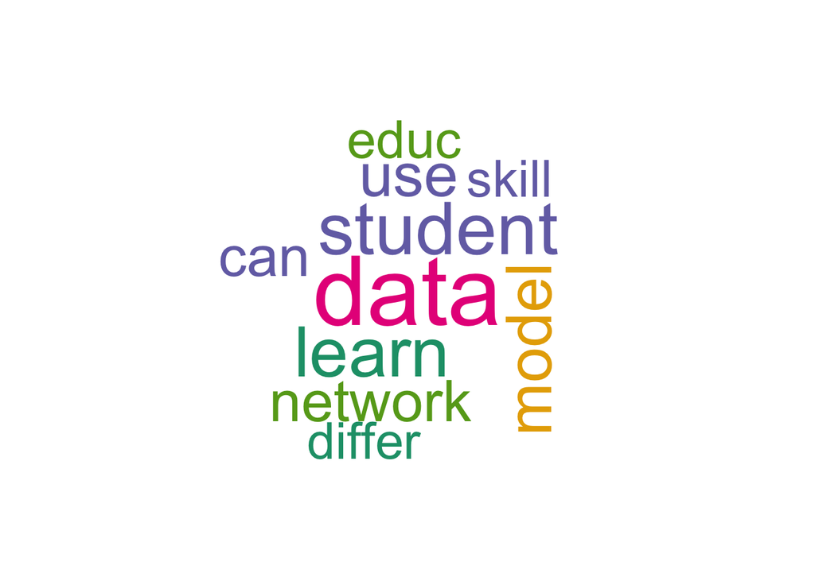

```r
#Define the colors the cloud will use
col=brewer.pal(6,"Dark2")
#Generate cloud, make sure your window is large enough to see it
wordcloud(corpus, min.freq=500, scale=c(5,2),rot.per = 0.25,
          random.color=T, max.word=45, random.order=F,colors=col)
```

# Sentiment Analysis

### Match words in corpus to lexicons of positive & negative words

```r
#Upload positive and negative word lexicons
positive <- readLines("positive-words.txt")
negative <- readLines("negative-words.txt")

#Search for matches between each word and the two lexicons
D1$positive <- tm_term_score(tdm.corpus, positive)
D1$negative <- tm_term_score(tdm.corpus, negative)

#Generate an overall pos-neg score for each line
D1$score <- D1$positive - D1$negative
```

#Checking the data again

```r
D1 %>% head
```

```
## # A tibble: 6 x 6
##   Title                    Notes                    week positive negative score
##   <chr>                    <chr>                   <int>    <dbl>    <dbl> <dbl>
## 1 Learning Analytics and ~ "While Learning Analyt~     2        3        0     3
## 2 Data wranglers: human i~ "LA seen as a feedback~     4        9        1     8
## 3 Saturday Morning Breakf~ "Comic: starts w/ 90% ~     3        1        1     0
## 4 Translating Learning in~ "There has been an exp~     3        4        5    -1
## 5 Analyzing the Longitudi~ "research has not paid~     7        1        1     0
## 6 RStudio Cheat Sheets     "Data Wrangling &; tid~     2        0        4    -4
```

## Using ggplot Generate a visualization of the mean sentiment score over weeks, remove rows that have readings from other classes (NA for weeks). You will need to summarize your data to achieve this.

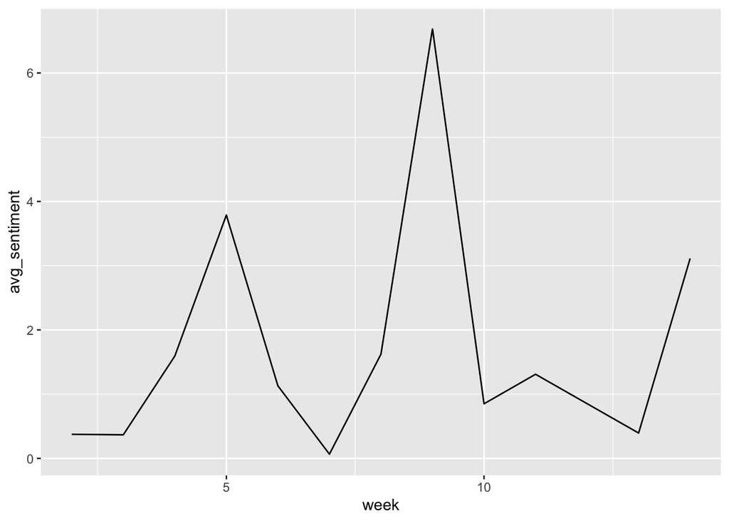

```r
D1 %>% filter(!(is.na(Notes))) %>% group_by(week) %>% summarize(avg_sentiment = mean(score)) %>% ggplot + geom_line(mapping = aes(x = week, y = avg_sentiment))
```

# LDA Topic Modelling

Using the same csv file you have generated the LDA analysis will treat each row of the data frame as a document. Does this make sense for generating topics? This makes sense for generating topics as the rows have notes along the same topic.

```r
#Term Frequency Inverse Document Frequency
dtm.tfi <- DocumentTermMatrix(corpus, control = list(weighting = weightTf))

#Remove very uncommon terms (term freq inverse document freq < 0.1)
dtm.tfi <- dtm.tfi[,dtm.tfi$v >= 0.1]

#Remove non-zero entries
rowTotals <- apply(dtm.tfi , 1, sum) #Find the sum of words in each Document
dtm.tfi2   <- dtm.tfi[rowTotals> 0, ] #Divide by sum across rows
```

```r
#Identify rows with zero entries
#Remove these rows from original dataset
zerorows<- which(rowTotals %in% c(0))
```

```r
D1 <- D1[-c(zerorows),]
```

```r
lda.model = LDA(dtm.tfi2, k = 5, seed = 150)
```

```r
terms(lda.model, k = 10)
```

```
##       Topic 1      Topic 2   Topic 3        Topic 4   Topic 5
##  [1,] "learn"      "model"   "network"      "data"    "student"
##  [2,] "data"       "skill"   "data"         "student" "model"
##  [3,] "educ"       "data"    "actor"        "learn"   "knowledg"
##  [4,] "edm"        "use"     "social"       "use"     "learn"
##  [5,] "research"   "student" "relat"        "can"     "predict"
##  [6,] "use"        "method"  "use"          "cluster" "perform"
##  [7,] "lak"        "set"     "can"          "educ"    "program"
##  [8,] "understand" "learn"   "relationship" "analyt"  "cours"
##  [9,] "measur"     "game"    "measur"       "make"    "differ"
## [10,] "can"        "item"    "tie"          "analysi" "use"
```

```r
D1$topic <- topics(lda.model)
```

What does an LDA topic represent? An LDA topic represents a set of words or terms spread across one or many documents. The algorithm helps represent the distribution of the given number of topics across the collection of documents.

# Final Task

Find a set of documents, perhaps essays you have written or articles you have available and complete an LDA analysis of those documents. Does the method group documents as you would expect?

```r
vidyadata <- read_csv("/Users/vidyamadhavan/Desktop/HUDK\ 4050/HUDK\ 4051\ SQL\ +\ Pred/Vidya\ Pred/natural-language-processing/vidya_reflection/Reflection_Data\ Contexts_\ Economics.txt", col_names = FALSE)
view(vidyadata)
```

```r
D7 <- lapply(vidyadata, read_lines)
D7<- gsub("<.*?>", "", D7)
D7<- gsub("nbsp", "" , D7)
D7 <- gsub("nbspnbspnbsp", "" , D7)
D7 <- gsub("<U+00A0><U+00A0><U+00A0>", "" , D7)
D7 <- gsub("“", "" , D7)
D7 <- gsub("—", "" , D7)
D7 <- gsub("’s", "" , D7)
D8 <- Corpus(VectorSource(D7))
```

```r
D8<- tm_map(D8, stripWhitespace)
D8<- tm_map(D8, tolower)
D8 <- tm_map(D8, removeWords, stopwords('english'))
D8 <- tm_map(D8, stemDocument)
 #Remove numbers
D8<- tm_map(D8, removeNumbers)
 #remove punctuation
D8 <- tm_map(D8, removePunctuation)
D9 <- DocumentTermMatrix(D8, control = list(weighting = weightTf))
D9 <- D9[,D9$v >= 0.1]

 #Remove non-zero entries
D9_rowTotals <- apply(D9 , 1, sum)
D10 <- D9[D9_rowTotals> 0, ]

 #Identify rows with zero entries
D9_zero_rows<-which(D9_rowTotals %in% c(0))
D9.model = LDA(D10, k = 10, seed = 100)
terms(D9.model, k = 10)
```

```
##       Topic 1    Topic 2       Topic 3    Topic 4     Topic 5
##  [1,] "research" "data"        "data"     "data"      "data"
##  [2,] "project"  "research"    "research" "project"   "project"
##  [3,] "boy"      "project"     "project"  "manag"     "creflection"
##  [4,] "data"     "creflection" "overview" "research"  "economics"
##  [5,] "contexts" "overview"    "services" "overview"  "adolesc"
##  [6,] "manag"    "regard"      "fields"   "economics" "qualit"
##  [7,] "services" "gender"      "generat"  "sensit"    "evolv"
##  [8,] "adolesc"  "fields"      "keep"     "regard"    "boy"
##  [9,] "keep"     "sensit"      "gender"   "fields"    "regard"
## [10,] "costs"    "qualit"      "manag"    "evolv"     "gender"
##       Topic 6       Topic 7    Topic 8    Topic 9     Topic 10
##  [1,] "data"        "data"     "data"     "data"      "manag"
##  [2,] "manag"       "manag"    "research" "project"   "contexts"
##  [3,] "equality"    "cost"     "manag"    "research"  "research"
##  [4,] "costs"       "evolv"    "project"  "economics" "evolv"
##  [5,] "contexts"    "regard"   "equality" "cost"      "services"
##  [6,] "keep"        "equality" "fields"   "costs"     "sensit"
##  [7,] "adolesc"     "boy"      "boy"      "generat"   "adolesc"
##  [8,] "creflection" "qualit"   "cost"     "sensit"    "overview"
##  [9,] "fields"      "keep"     "overview" "social"    "gender"
## [10,] "social"      "services" "gender"   "qualit"    "economics"
```

```r
D11 <- lapply(vidyadata, read_lines, n_max = 1)
corpus1 <- VCorpus(VectorSource(vidyadata))
corpus1 <- tm_map(corpus1, PlainTextDocument, lazy = TRUE)
```

```r
tdm.corpus1 <- TermDocumentMatrix(corpus1)
```

```r
dtm.tfi3 <- DocumentTermMatrix(corpus1, control = list(weighting = weightTf))
dtm.tfi3 <- dtm.tfi3[,dtm.tfi3$v >= 0.1]
lda.model = LDA(dtm.tfi3, k = 3, seed = 150)
```

```r
terms(lda.model, k = 10)
```

```
##       Topic 1       Topic 2       Topic 3
##  [1,] "data"        "management"  "data"
##  [2,] "research"    "project"     "research"
##  [3,] "management"  "evolving"    "fields"
##  [4,] "with"        "cost"        "social"
##  [5,] "project"     "equality"    "economics"
##  [6,] "services"    "reflection:" "project"
##  [7,] "boys’" "regarding"   "gender"
##  [8,] "sensitivity" "other"       "costs:"
##  [9,] "the"         "overview"    "management"
## [10,] "gender"      "qualitative" "equality"
```

#End